# 02 Data Cleaning

2022-07-18

# Data cleaning and quality control

The objective of the data cleaning and quality control is primarily to remove technology artifacts that may dampen biological signal. These include stressed cells, low-count, and doublets. However, some biological signals may need to be removed as these are non-canonical to the experiment.

We start off by loading a previously created object using, and the published data set using the function `data`

```r
library(Seurat)
library(tidyverse)
devtools::load_all()
```

```
#> ℹ Loading rnaseq_training
```

```r
## load data
data(pre.fibroS, soleS)
```

The object currently contains 32738 features and 16062 cells. Whereas the published object had a few less featuers and cells, 21352, and 15457, respectively.

## Percent Mitochondria

A measure of stress in cells and sample handling

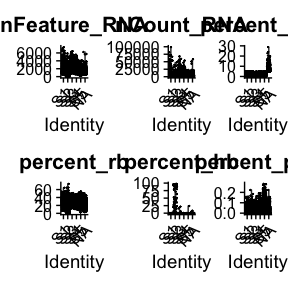

```r
## Percentage mitochondrial genes
pre.fibroS <- PercentageFeatureSet(pre.fibroS, pattern = "^MT-", col.name = "percent_mt")
## Percentage ribosomal genes
pre.fibroS <- PercentageFeatureSet(pre.fibroS, pattern = "^RP[SL]", col.name = "percent_rb")
## Percentage hemoglobin genes - includes all genes starting with HB except HBP.
pre.fibroS <- PercentageFeatureSet(pre.fibroS, pattern = "^HB[^(P)]", col.name = "percent_hb")
## Percentage platelet expression
pre.fibroS <- PercentageFeatureSet(pre.fibroS, pattern = "PECAM1|PF4", col.name = "percent_plat")

## plots
features_of_interest <- c("nFeature_RNA", "nCount_RNA", "percent_mt", "percent_rb", "percent_hb", "percent_plat")

VlnPlot(pre.fibroS, group.by = "subj",
        features = features_of_interest, pt.size = 0.1, ncol = 3) +
  NoLegend()
```

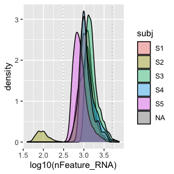

```r
## find limits for nFeature_RNA
pre.fibroS[[]] %>%
  ggplot(aes(x = log10(nFeature_RNA), fill = subj)) +
  geom_density(alpha = 0.4) +
  geom_vline(xintercept = c(2.5, 3.7), col = "gray", lty = 3)
```

```r
10^c(2.5, 3.7)
```

```
#> [1]  316.2278 5011.8723
```

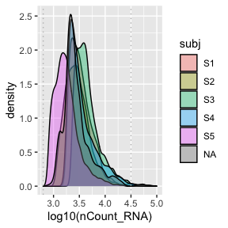

```r
## find limits for nCount_RNA
pre.fibroS[[]] %>%
  ggplot(aes(x = log10(nCount_RNA), fill = subj)) +
  geom_density(alpha = 0.4) +
  geom_vline(xintercept = c(2.8, 4.5), col = "gray", lty = 3)
```

```r
10^c(2.8, 4.5)
```

```
#> [1]   630.9573 31622.7766
```

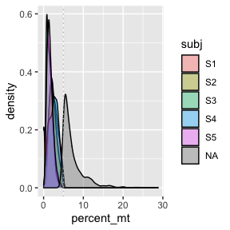

```r
## find limits for percent_mt
pre.fibroS[[]] %>%
  ggplot(aes(x = percent_mt, fill = subj)) +
  geom_density(alpha = 0.4) +
  geom_vline(xintercept = 5, col = "gray", lty = 3)
```

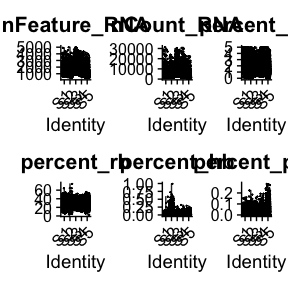

```r
fibroS1 <- pre.fibroS %>%
  subset(nFeature_RNA > 316 &
           nFeature_RNA <= 5012 &
           nCount_RNA > 630 &
           nCount_RNA <= 31623 &
           percent_mt <= 5 &
           percent_hb <= 1 )

fibroS1 %>%
  VlnPlot(group.by = "subj",
          features = features_of_interest, pt.size = 0.1, ncol = 3) +
  NoLegend()
```

Now that we have a uniform set of cells, with relatively uniform quality metrics we can proceed with the analysis in the next vignette. and save the `fibroS1` object now containing 15070 cells

*NOTE*: In palbociclib treated cells we observe a high mitochondrial gene expression signal. In that instance we chose not to remove it based on biological evidence. That can be the case here as well.

## removal lowly and unexpressed genes in the population

```r
unexpressed.genes <- rowSums(GetAssay(object = fibroS1, assay = "RNA")@counts) == 0
unexpressed.genes <- names(unexpressed.genes)[unexpressed.genes]
low.expressed <- rowSums(GetAssay(object = fibroS1, assay = "RNA")@counts) <= 10
low.expressed <- names(low.expressed)[low.expressed]
length(low.expressed)
```

```
#> [1] 14835
```

Based on Seurat’s documentation the best solution, is to perform the filtering prior to creating the seurat object, thus, we’ll re-read the data, and remove low abundance genes, and recreate the object.

```r
a.fibro <- Read10X("data-raw/filtered_feature_bc_matrix/")

all.genes <- rownames(a.fibro)
genes2keep <- setdiff(all.genes, low.expressed)

## Here we'll perform both filtering steps, both to keep abundant genes, and
## good quality cells
b.fibro <- a.fibro[genes2keep, colnames(fibroS1)]

fibroS <- CreateSeuratObject(b.fibro, project = "Fibroblasts_Sole") %>%
  PercentageFeatureSet(pattern = "^MT-", col.name = "percent_mt") %>%
  PercentageFeatureSet(pattern = "^RP[SL]", col.name = "percent_rb") %>%
  PercentageFeatureSet(pattern = "^HB[^(P)]", col.name = "percent_hb") %>%
  PercentageFeatureSet(pattern = "PECAM1|PF4", col.name = "percent_plat")
tmp <- soleS[[]][colnames(fibroS),] %>% select(subj, age)
tmp <- merge(fibroS[[]], tmp, by = 0, all.x = TRUE, sort = FALSE)
rownames(tmp) <- tmp$Row.names
tmp <- tmp[rownames(fibroS[[]]), ]  %>% select(-Row.names)

all(rownames(tmp) == rownames(fibroS[[]]))
```

```
#> [1] TRUE
```

```r
fibroS@meta.data <- tmp

usethis::use_data(fibroS1, fibroS, overwrite = TRUE)
```

```
#> ✔ Setting active project to '/Users/gularter/mskcc/dev/rnaseq_training'
#> ✔ Saving 'fibroS1', 'fibroS' to 'data/fibroS1.rda', 'data/fibroS.rda'
#> • Document your data (see 'https://r-pkgs.org/data.html')
```